# FINAL_Term_Deposit_Project_GaneshBalusait

##### Decision Tree - Gini

```
model_selection: DecisionTreeClassifier(class_weight=None, criterion='gini', max_depth=3,
            max_features=None, max_leaf_nodes=None,
            min_impurity_decrease=0.0, min_impurity_split=None,
            min_samples_leaf=5, min_samples_split=2,
            min_weight_fraction_leaf=0.0, presort=False, random_state=None,
            splitter='best')

----------------------------------------------------------------------------------------------------
Confusion Matrix:
```

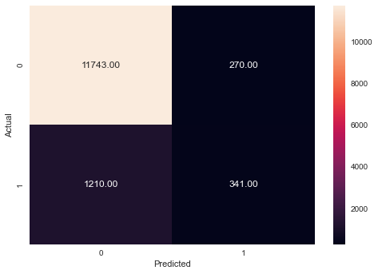

```
None
```

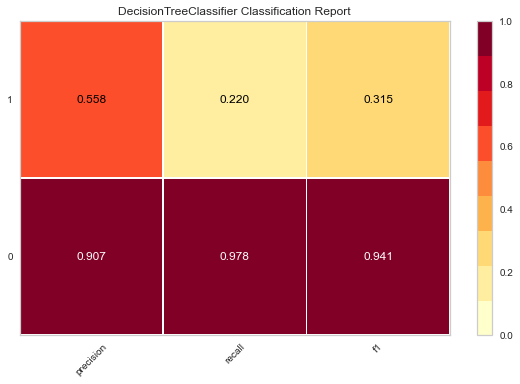

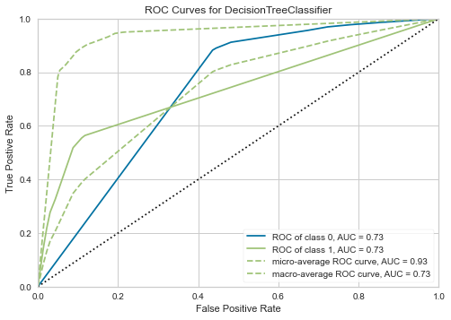

```python
from sklearn.tree import DecisionTreeClassifier

algorithms(DecisionTreeClassifier(criterion='gini',max_depth=3,min_samples_leaf=5))
```

```python
MLA_columns = []
DTG = pd.DataFrame(columns = MLA_columns)


row_index = 0
for algss in [model_s]:
    print(algss)

    MLA_name = 'DecisionTreeClassifier-Gini'
    DTG.loc[row_index,'MLA Name'] = MLA_name
    DTG.loc[row_index, 'Train Accuracy'] = round(algss.score(X_train, y_train), 4)
    DTG.loc[row_index, 'Test Accuracy'] = round(algss.score(X_test, y_test), 4)
    DTG.loc[row_index, 'Accuracy Score'] = round(accuracy_score(y_test, y_predict), 4)
    DTG.loc[row_index, 'MAE'] = round(mean_absolute_error(y_test, y_predict), 4)
    DTG.loc[row_index, 'Recall'] = round(recall_score(y_test, y_predict), 4)
    DTG.loc[row_index, 'F1 Score'] = round(f1_score(y_test, y_predict), 4)
    DTG.loc[row_index, 'ROC AUC Score'] = round(roc_auc_score(y_test, y_predict), 4)

    row_index+=1

DTG
```

```
DecisionTreeClassifier(class_weight=None, criterion='gini', max_depth=3,
            max_features=None, max_leaf_nodes=None,
            min_impurity_decrease=0.0, min_impurity_split=None,
            min_samples_leaf=5, min_samples_split=2,
            min_weight_fraction_leaf=0.0, presort=False, random_state=None,
            splitter='best')
```

|  | MLA Name | Train Accuracy | Test Accuracy | Accuracy Score | MAE | Recall | F1 Score | ROC AUC Score |
| --- | --- | --- | --- | --- | --- | --- | --- | --- |
| 0 | DecisionTreeClassifier-Gini | 0.891 | 0.8909 | 0.8909 | 0.1091 | 0.2199 | 0.3154 | 0.5987 |

##### Observations

- To use Decision Tree model and use the Gini, to find out the level of metrics.

#### Ensenble Techniques

- Random Forest Classifier
- Bagging Classifier
- AdaBoosting Classifier

##### Random Forest Classifier

```
model_selection: RandomForestClassifier(bootstrap=True, class_weight=None, criterion='gini',
            max_depth=None, max_features='auto', max_leaf_nodes=None,
            min_impurity_decrease=0.0, min_impurity_split=None,
            min_samples_leaf=1, min_samples_split=2,
            min_weight_fraction_leaf=0.0, n_estimators=50, n_jobs=None,
            oob_score=False, random_state=None, verbose=0,
            warm_start=False)

----------------------------------------------------------------------------------------------------
Confusion Matrix:
```

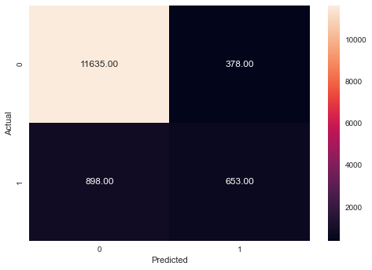

```
None
```

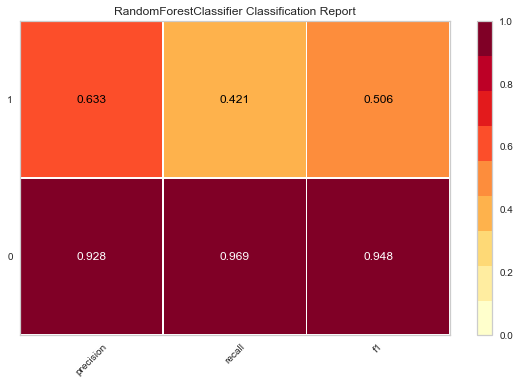

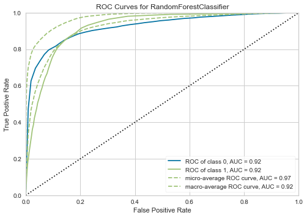

```python
from sklearn.ensemble import RandomForestClassifier

algorithms(RandomForestClassifier(n_estimators=50))
```

```python
MLA_columns = []
RFC = pd.DataFrame(columns = MLA_columns)


row_index = 0
for algss in [model_s]:
    print(algss)

    MLA_name = algss.__class__.__name__
    RFC.loc[row_index,'MLA Name'] = MLA_name
    RFC.loc[row_index, 'Train Accuracy'] = round(algss.score(X_train, y_train), 4)
    RFC.loc[row_index, 'Test Accuracy'] = round(algss.score(X_test, y_test), 4)
    RFC.loc[row_index, 'Accuracy Score'] = round(accuracy_score(y_test, y_predict), 4)
    RFC.loc[row_index, 'MAE'] = round(mean_absolute_error(y_test, y_predict), 4)
    RFC.loc[row_index, 'Recall'] = round(recall_score(y_test, y_predict), 4)
    RFC.loc[row_index, 'F1 Score'] = round(f1_score(y_test, y_predict), 4)
    RFC.loc[row_index, 'ROC AUC Score'] = round(roc_auc_score(y_test, y_predict), 4)

    row_index+=1

RFC
```

```
RandomForestClassifier(bootstrap=True, class_weight=None, criterion='gini',
            max_depth=None, max_features='auto', max_leaf_nodes=None,
            min_impurity_decrease=0.0, min_impurity_split=None,
            min_samples_leaf=1, min_samples_split=2,
            min_weight_fraction_leaf=0.0, n_estimators=50, n_jobs=None,
            oob_score=False, random_state=None, verbose=0,
            warm_start=False)
```

|  | MLA Name | Train Accuracy | Test Accuracy | Accuracy Score | MAE | Recall | F1 Score | ROC AUC Score |
| --- | --- | --- | --- | --- | --- | --- | --- | --- |
| 0 | RandomForestClassifier | 0.9998 | 0.9059 | 0.9059 | 0.0941 | 0.421 | 0.5058 | 0.6948 |

##### Observations

- To use Random Forest model and to find out the level of metrics.

##### Bagging Classifier

```
model_selection: BaggingClassifier(base_estimator=None, bootstrap=True,
         bootstrap_features=False, max_features=1.0, max_samples=0.7,
         n_estimators=50, n_jobs=None, oob_score=True, random_state=20,
         verbose=0, warm_start=False)

----------------------------------------------------------------------------------------------------
Confusion Matrix:
```

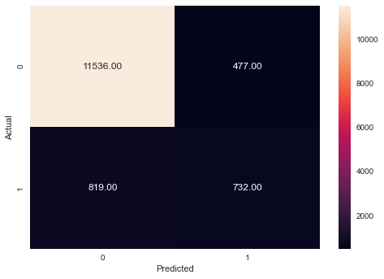

```
None
```

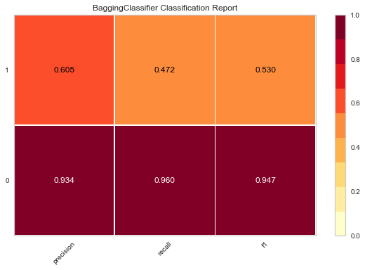

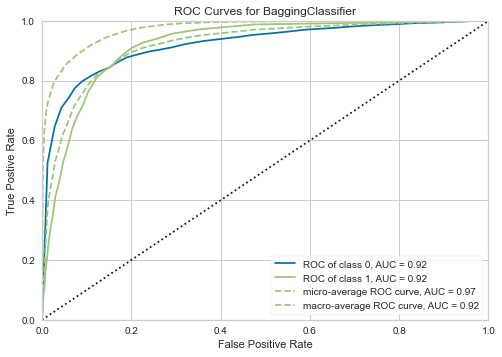

```python
from sklearn.ensemble import BaggingClassifier

algorithms(BaggingClassifier(n_estimators=50,max_samples=0.7,oob_score=True,random_state=20))
```

```python
MLA_columns = []
BGC = pd.DataFrame(columns = MLA_columns)


row_index = 0
for algss in [model_s]:
    print(algss)

    MLA_name = algss.__class__.__name__
    BGC.loc[row_index,'MLA Name'] = MLA_name
    BGC.loc[row_index, 'Train Accuracy'] = round(algss.score(X_train, y_train), 4)
    BGC.loc[row_index, 'Test Accuracy'] = round(algss.score(X_test, y_test), 4)
    BGC.loc[row_index, 'Accuracy Score'] = round(accuracy_score(y_test, y_predict), 4)
    BGC.loc[row_index, 'MAE'] = round(mean_absolute_error(y_test, y_predict), 4)
    BGC.loc[row_index, 'Recall'] = round(recall_score(y_test, y_predict), 4)
    BGC.loc[row_index, 'F1 Score'] = round(f1_score(y_test, y_predict), 4)
    BGC.loc[row_index, 'ROC AUC Score'] = round(roc_auc_score(y_test, y_predict), 4)

    row_index+=1

BGC
```

```
BaggingClassifier(base_estimator=None, bootstrap=True,
         bootstrap_features=False, max_features=1.0, max_samples=0.7,
         n_estimators=50, n_jobs=None, oob_score=True, random_state=20,
         verbose=0, warm_start=False)
```

|  | MLA Name | Train Accuracy | Test Accuracy | Accuracy Score | MAE | Recall | F1 Score | ROC AUC Score |
| --- | --- | --- | --- | --- | --- | --- | --- | --- |
| 0 | BaggingClassifier | 0.9935 | 0.9045 | 0.9045 | 0.0955 | 0.472 | 0.5304 | 0.7161 |

##### Observations

- To use Bagging Classifier model and to find out the level of metrics.

##### AdaBoost Classifier

```
model_selection: AdaBoostClassifier(algorithm='SAMME.R', base_estimator=None,
          learning_rate=1.0, n_estimators=50, random_state=20)

----------------------------------------------------------------------------------------------------
Confusion Matrix:
```

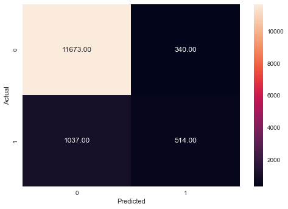

```
None
```

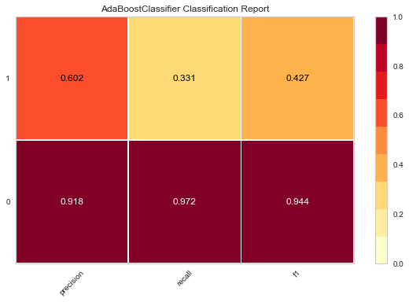

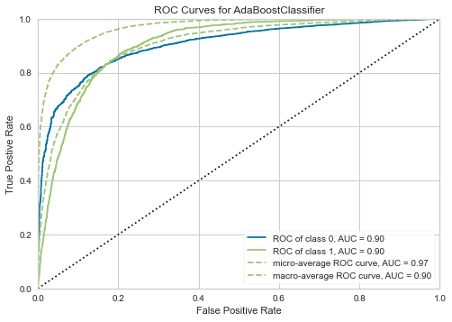

```python
from sklearn.ensemble import AdaBoostClassifier
algorithms(AdaBoostClassifier(n_estimators=50,learning_rate=1.0,random_state=20))
```

```python
MLA_columns = []
ABC = pd.DataFrame(columns = MLA_columns)


row_index = 0
for algss in [model_s]:
    print(algss)

    MLA_name = algss.__class__.__name__
    ABC.loc[row_index,'MLA Name'] = MLA_name
    ABC.loc[row_index, 'Train Accuracy'] = round(algss.score(X_train, y_train), 4)
    ABC.loc[row_index, 'Test Accuracy'] = round(algss.score(X_test, y_test), 4)
    ABC.loc[row_index, 'Accuracy Score'] = round(accuracy_score(y_test, y_predict), 4)
    ABC.loc[row_index, 'MAE'] = round(mean_absolute_error(y_test, y_predict), 4)
    ABC.loc[row_index, 'Recall'] = round(recall_score(y_test, y_predict), 4)
    ABC.loc[row_index, 'F1 Score'] = round(f1_score(y_test, y_predict), 4)
    ABC.loc[row_index, 'ROC AUC Score'] = round(roc_auc_score(y_test, y_predict), 4)

    row_index+=1

ABC
```

```
AdaBoostClassifier(algorithm='SAMME.R', base_estimator=None,
          learning_rate=1.0, n_estimators=50, random_state=20)
```

|  | MLA Name | Train Accuracy | Test Accuracy | Accuracy Score | MAE | Recall | F1 Score | ROC AUC Score |
| --- | --- | --- | --- | --- | --- | --- | --- | --- |
| 0 | AdaBoostClassifier | 0.8986 | 0.8985 | 0.8985 | 0.1015 | 0.3314 | 0.4274 | 0.6515 |

##### Observations

- To use AdaBoost Classifier model and to find out the level of metrics.

##### Gradient Boost Classifier

```
model_selection: GradientBoostingClassifier(criterion='friedman_mse', init=None,
              learning_rate=0.1, loss='deviance', max_depth=3,
              max_features=None, max_leaf_nodes=None,
              min_impurity_decrease=0.0, min_impurity_split=None,
              min_samples_leaf=1, min_samples_split=2,
              min_weight_fraction_leaf=0.0, n_estimators=50,
              n_iter_no_change=None, presort='auto', random_state=22,
              subsample=1.0, tol=0.0001, validation_fraction=0.1,
              verbose=0, warm_start=False)

----------------------------------------------------------------------------------------------------
Confusion Matrix:
```

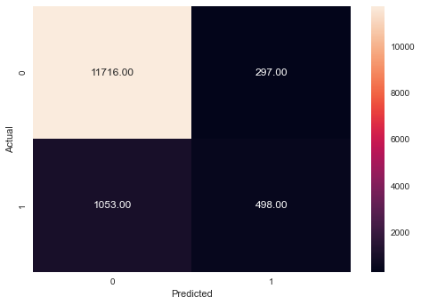

```
None
```

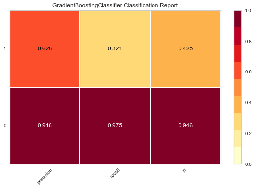

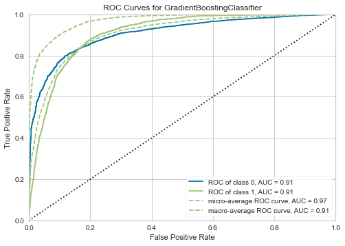

```python
from sklearn.ensemble import GradientBoostingClassifier

algorithms(GradientBoostingClassifier(n_estimators=50, learning_rate=0.1,random_state=22))
```

```python
MLA_columns = []
GBC = pd.DataFrame(columns = MLA_columns)


row_index = 0
for algss in [model_s]:
    print(algss)

    MLA_name = algss.__class__.__name__
    GBC.loc[row_index,'MLA Name'] = MLA_name
    GBC.loc[row_index, 'Train Accuracy'] = round(algss.score(X_train, y_train), 4)
    GBC.loc[row_index, 'Test Accuracy'] = round(algss.score(X_test, y_test), 4)
    GBC.loc[row_index, 'Accuracy Score'] = round(accuracy_score(y_test, y_predict), 4)
    GBC.loc[row_index, 'MAE'] = round(mean_absolute_error(y_test, y_predict), 4)
    GBC.loc[row_index, 'Recall'] = round(recall_score(y_test, y_predict), 4)
    GBC.loc[row_index, 'F1 Score'] = round(f1_score(y_test, y_predict), 4)
    GBC.loc[row_index, 'ROC AUC Score'] = round(roc_auc_score(y_test, y_predict), 4)

    row_index+=1

GBC
```

```
GradientBoostingClassifier(criterion='friedman_mse', init=None,
              learning_rate=0.1, loss='deviance', max_depth=3,
              max_features=None, max_leaf_nodes=None,
              min_impurity_decrease=0.0, min_impurity_split=None,
              min_samples_leaf=1, min_samples_split=2,
              min_weight_fraction_leaf=0.0, n_estimators=50,
              n_iter_no_change=None, presort='auto', random_state=22,
              subsample=1.0, tol=0.0001, validation_fraction=0.1,
              verbose=0, warm_start=False)
```

|  | MLA Name | Train Accuracy | Test Accuracy | Accuracy Score | MAE | Recall | F1 Score | ROC AUC Score |
| --- | --- | --- | --- | --- | --- | --- | --- | --- |
| 0 | GradientBoostingClassifier | 0.905 | 0.9005 | 0.9005 | 0.0995 | 0.3211 | 0.4246 | 0.6482 |

##### Observations

- To use Gradient Boost Classifier model and to find out the level of metrics.

##### Using Grid Search CV to tune the hyper parameter the Bagging and Gradient Boosting Classifier

##### GridSearch to tune the hyper parameter --> Bagging Classifier

```python
from sklearn.model_selection import GridSearchCV
bag=BaggingClassifier()
a=bag.get_params()
a
```

```
{'base_estimator': None,
 'bootstrap': True,
 'bootstrap_features': False,
 'max_features': 1.0,
 'max_samples': 1.0,
 'n_estimators': 10,
 'n_jobs': None,
 'oob_score': False,
 'random_state': None,
 'verbose': 0,
 'warm_start': False}
```

```python
parameters = {'max_samples':[0.5,1.0],'max_features':[1,2,4],'bootstrap':[True, False],'bootstrap_features':[True,False],
             'n_estimators':[10,15,20,25,30,35]}

gridSearch_Bagging = GridSearchCV(estimator=bag,param_grid=parameters,scoring='accuracy',cv=5,n_jobs=-1)
gridSearch_Bagging = gridSearch_Bagging.fit(X_train, y_train)
```

- Tuning the hyper parameter to fit the model

```python
accuracy = gridSearch_Bagging.best_score_
```

```python
accuracy
```

```
0.8881094574525231
```

```python
gridSearch_Bagging.best_params_
```

```
{'bootstrap': False,
 'bootstrap_features': False,
 'max_features': 4,
 'max_samples': 1.0,
 'n_estimators': 30}
```

```python
gridSearch_Bagging.best_estimator_
```

```
BaggingClassifier(base_estimator=None, bootstrap=False,
         bootstrap_features=False, max_features=4, max_samples=1.0,
         n_estimators=30, n_jobs=None, oob_score=False, random_state=None,
         verbose=0, warm_start=False)
```

```
model_selection: BaggingClassifier(base_estimator=None, bootstrap=False,
         bootstrap_features=False, max_features=4, max_samples=1.0,
         n_estimators=30, n_jobs=None, oob_score=False, random_state=None,
         verbose=0, warm_start=False)

----------------------------------------------------------------------------------------------------
Confusion Matrix:
```

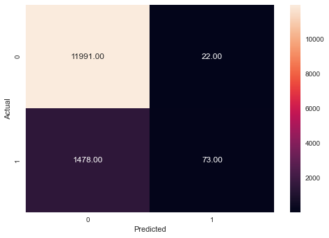

```
None
```

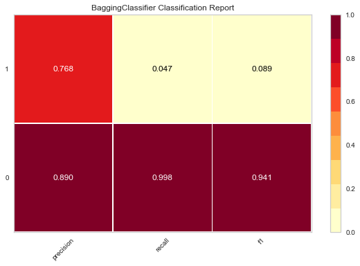

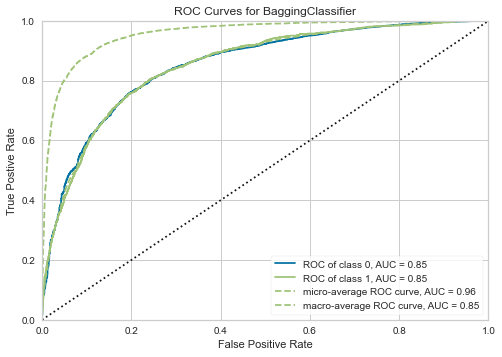

```python
algorithms(gridSearch_Bagging.best_estimator_)
```

```python
MLA_columns = []
BCGSCV = pd.DataFrame(columns = MLA_columns)


row_index = 0
for algss in [model_s]:
    print(algss)

    MLA_name = 'Bagging Classifier GSCV'
    BCGSCV.loc[row_index,'MLA Name'] = MLA_name
    BCGSCV.loc[row_index, 'Train Accuracy'] = round(algss.score(X_train, y_train), 4)
    BCGSCV.loc[row_index, 'Test Accuracy'] = round(algss.score(X_test, y_test), 4)
    BCGSCV.loc[row_index, 'Accuracy Score'] = round(accuracy_score(y_test, y_predict), 4)
    BCGSCV.loc[row_index, 'MAE'] = round(mean_absolute_error(y_test, y_predict), 4)
    BCGSCV.loc[row_index, 'Recall'] = round(recall_score(y_test, y_predict), 4)
    BCGSCV.loc[row_index, 'F1 Score'] = round(f1_score(y_test, y_predict), 4)
    BCGSCV.loc[row_index, 'ROC AUC Score'] = round(roc_auc_score(y_test, y_predict), 4)

    row_index+=1

BCGSCV
```

```
BaggingClassifier(base_estimator=None, bootstrap=False,
         bootstrap_features=False, max_features=4, max_samples=1.0,
         n_estimators=30, n_jobs=None, oob_score=False, random_state=None,
         verbose=0, warm_start=False)
```

|  | MLA Name | Train Accuracy | Test Accuracy | Accuracy Score | MAE | Recall | F1 Score | ROC AUC Score |
| --- | --- | --- | --- | --- | --- | --- | --- | --- |
| 0 | Bagging Classifier GSCV | 0.913 | 0.8894 | 0.8894 | 0.1106 | 0.0471 | 0.0887 | 0.5226 |

##### Observations

- To use Bagging Classifier model to tune the hyper parameter and to find out the level of metrics.

##### GridSearch to tune the hyper parameter --> Gradient Boosting

```python
gbc=GradientBoostingClassifier()
gb=gbc.get_params()
gb
```

```
{'criterion': 'friedman_mse',
 'init': None,
 'learning_rate': 0.1,
 'loss': 'deviance',
 'max_depth': 3,
 'max_features': None,
 'max_leaf_nodes': None,
 'min_impurity_decrease': 0.0,
 'min_impurity_split': None,
 'min_samples_leaf': 1,
 'min_samples_split': 2,
 'min_weight_fraction_leaf': 0.0,
 'n_estimators': 100,
 'n_iter_no_change': None,
 'presort': 'auto',
 'random_state': None,
 'subsample': 1.0,
 'tol': 0.0001,
 'validation_fraction': 0.1,
 'verbose': 0,
 'warm_start': False}
```

```python
grid_params = [{'learning_rate':[0.01, 0.05, 0.1, 0.2],
               'min_samples_split':[2,3,4],'min_samples_leaf':[1],'max_depth':[3,4,5],}]

gridSearch_GBC = GridSearchCV(estimator=gbc,param_grid=grid_params, scoring='accuracy',cv=5,
                              n_jobs=-1)
gridSearch_GBC.fit(X_train, y_train)
```

```
GridSearchCV(cv=5, error_score='raise-deprecating',
       estimator=GradientBoostingClassifier(criterion='friedman_mse', init=None,
              learning_rate=0.1, loss='deviance', max_depth=3,
              max_features=None, max_leaf_nodes=None,
              min_impurity_decrease=0.0, min_impurity_split=None,
              min_samples_leaf=1, min_sampl...      subsample=1.0, tol=0.0001, validation_fraction=0.1,
              verbose=0, warm_start=False),
       fit_params=None, iid='warn', n_jobs=-1,
       param_grid=[{'learning_rate': [0.01, 0.05, 0.1, 0.2], 'min_samples_split': [2, 3, 4], 'min_samples_leaf': [1], 'max_depth': [3, 4, 5]}],
       pre_dispatch='2*n_jobs', refit=True, return_train_score='warn',
       scoring='accuracy', verbose=0)
```

```python
accuracy_GBC = gridSearch_GBC.best_score_
accuracy_GBC
```

```
0.906815811925301
```

```python
gridSearch_GBC.best_estimator_
```

```
GradientBoostingClassifier(criterion='friedman_mse', init=None,
              learning_rate=0.1, loss='deviance', max_depth=5,
              max_features=None, max_leaf_nodes=None,
              min_impurity_decrease=0.0, min_impurity_split=None,
              min_samples_leaf=1, min_samples_split=2,
              min_weight_fraction_leaf=0.0, n_estimators=100,
              n_iter_no_change=None, presort='auto', random_state=None,
              subsample=1.0, tol=0.0001, validation_fraction=0.1,
              verbose=0, warm_start=False)
```

```
model_selection: GradientBoostingClassifier(criterion='friedman_mse', init=None,
              learning_rate=0.1, loss='deviance', max_depth=5,
              max_features=None, max_leaf_nodes=None,
              min_impurity_decrease=0.0, min_impurity_split=None,
              min_samples_leaf=1, min_samples_split=2,
              min_weight_fraction_leaf=0.0, n_estimators=100,
              n_iter_no_change=None, presort='auto', random_state=None,
              subsample=1.0, tol=0.0001, validation_fraction=0.1,
              verbose=0, warm_start=False)

----------------------------------------------------------------------------------------------------
Confusion Matrix:
```

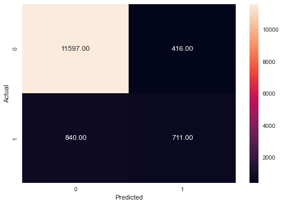

```
None
```

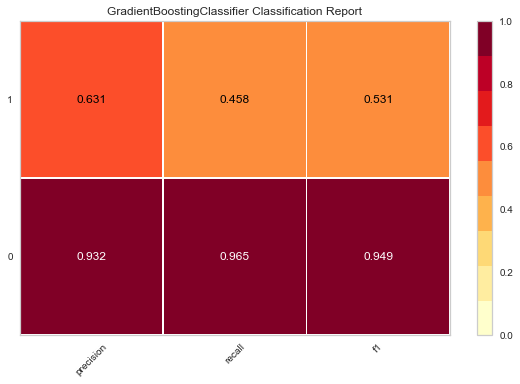

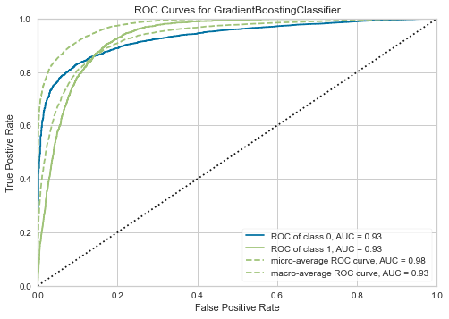

```python
algorithms(gridSearch_GBC.best_estimator_)
```

```python
MLA_columns = []
GBGSCV = pd.DataFrame(columns = MLA_columns)


row_index = 0
for algss in [model_s]:
    print(algss)

    MLA_name = 'Gradient Boosting-GSCV'
    GBGSCV.loc[row_index,'MLA Name'] = MLA_name
    GBGSCV.loc[row_index, 'Train Accuracy'] = round(algss.score(X_train, y_train), 4)
    GBGSCV.loc[row_index, 'Test Accuracy'] = round(algss.score(X_test, y_test), 4)
    GBGSCV.loc[row_index, 'Accuracy Score'] = round(accuracy_score(y_test, y_predict), 4)
    GBGSCV.loc[row_index, 'MAE'] = round(mean_absolute_error(y_test, y_predict), 4)
    GBGSCV.loc[row_index, 'Recall'] = round(recall_score(y_test, y_predict), 4)
    GBGSCV.loc[row_index, 'F1 Score'] = round(f1_score(y_test, y_predict), 4)
    GBGSCV.loc[row_index, 'ROC AUC Score'] = round(roc_auc_score(y_test, y_predict), 4)

    row_index+=1

GBGSCV
```

```
GradientBoostingClassifier(criterion='friedman_mse', init=None,
              learning_rate=0.1, loss='deviance', max_depth=5,
              max_features=None, max_leaf_nodes=None,
              min_impurity_decrease=0.0, min_impurity_split=None,
              min_samples_leaf=1, min_samples_split=2,
              min_weight_fraction_leaf=0.0, n_estimators=100,
              n_iter_no_change=None, presort='auto', random_state=None,
              subsample=1.0, tol=0.0001, validation_fraction=0.1,
              verbose=0, warm_start=False)
```

|  | MLA Name | Train Accuracy | Test Accuracy | Accuracy Score | MAE | Recall | F1 Score | ROC AUC Score |
| --- | --- | --- | --- | --- | --- | --- | --- | --- |
| 0 | Gradient Boosting-GSCV | 0.9291 | 0.9074 | 0.9074 | 0.0926 | 0.4584 | 0.531 | 0.7119 |

##### Observations

- To use Gardient Boosting Classifier model to tune the hyper parameter and to find out the level of metrics.

#### Comparing the Non-Ensemble and Ensemble Classifiers and to evulate the best model.

```python
results = pd.concat([LR,DTE,DTG,RFC,BGC,ABC,GBC,BCGSCV,GBGSCV],ignore_index=True)
results
```

|  | MLA Name | Train Accuracy | Test Accuracy | Accuracy Score | MAE | Recall | F1 Score | ROC AUC Score |
| --- | --- | --- | --- | --- | --- | --- | --- | --- |
| 0 | LogisticRegression | 0.8111 | 0.8062 | 0.8062 | 0.1938 | 0.7859 | 0.4812 | 0.7974 |
| 1 | DecisionTreeClassifier-entropy | 0.8892 | 0.8899 | 0.8899 | 0.1101 | 0.1799 | 0.2719 | 0.5807 |
| 2 | DecisionTreeClassifier-Gini | 0.8910 | 0.8909 | 0.8909 | 0.1091 | 0.2199 | 0.3154 | 0.5987 |
| 3 | RandomForestClassifier | 0.9998 | 0.9059 | 0.9059 | 0.0941 | 0.4210 | 0.5058 | 0.6948 |
| 4 | BaggingClassifier | 0.9935 | 0.9045 | 0.9045 | 0.0955 | 0.4720 | 0.5304 | 0.7161 |
| 5 | AdaBoostClassifier | 0.8986 | 0.8985 | 0.8985 | 0.1015 | 0.3314 | 0.4274 | 0.6515 |
| 6 | GradientBoostingClassifier | 0.9050 | 0.9005 | 0.9005 | 0.0995 | 0.3211 | 0.4246 | 0.6482 |
| 7 | Bagging Classifier GSCV | 0.9130 | 0.8894 | 0.8894 | 0.1106 | 0.0471 | 0.0887 | 0.5226 |
| 8 | Gradient Boosting-GSCV | 0.9291 | 0.9074 | 0.9074 | 0.0926 | 0.4584 | 0.5310 | 0.7119 |

### Conclusion

- Out of all the algorithms, The GradientBoosting Classifier is the best performance. The accuracy of tuned into 90.74%.
- The Hyper parameter tuned Gradien Boosting technique to predict the potential customers who are relatively more likely to subscribe term deposit.